# Raichura_Yash-PS2

## Problem Set 2

This is the linear algebra/matrix manipulation problem set. It has three purposes: a) make you better and more confident with matrices in general, matrices in python, and keeping and manipulating different data in matrix form; b) get more used with matrix multiplication and transformation matrices (as mathematical objects and operations); and finally c) learn more matplotlib. The extra credit question also asks you to dig deep into it.

1. Please write clearly! Answer each question in a way that if the code chunks are removed from your document, the result is still readable!
2. Please keep data file in the same folder as your code, and read these w/o any path like "data.csv" (or "./data.csv"). This makes it much easier to check your code!

## Preliminaries

You should also make sure the following libraries load correctly. Below are a few basic data description tasks already done for you.

```python
#IPython is what you are using now to run the notebook
import IPython
print( "IPython version:      %6.6s (need at least 1.0)" % IPython.__version__)

# Numpy is a library for working with arrays and matrices
import numpy as np
print( "Numpy version:        %6.6s (need at least 1.7.1)" % np.__version__)

# SciPy implements many different numerical algorithms
import scipy as sp
print( "SciPy version:        %6.6s (need at least 0.12.0)" % sp.__version__)

# Pandas makes working with data tables easier
import pandas as pd
print( "Pandas version:       %6.6s (need at least 0.11.0)" % pd.__version__)

# Module for plotting
import matplotlib.pyplot as plt
from pylab import *
print( "Mapltolib version:    %6.6s (need at least 1.2.1)" %
       matplotlib.__version__)
%matplotlib inline
# necessary for in-line graphics

# SciKit Learn implements several Machine Learning algorithms
import sklearn
print( "Scikit-Learn version: %6.6s (need at least 0.13.1)" %
       sklearn.__version__)
```

```
IPython version:       7.8.0 (need at least 1.0)
Numpy version:        1.16.5 (need at least 1.7.1)
SciPy version:         1.3.1 (need at least 0.12.0)
Pandas version:       0.25.1 (need at least 0.11.0)
Mapltolib version:     3.1.1 (need at least 1.2.1)
Scikit-Learn version: 0.21.3 (need at least 0.13.1)
```

# 1 Rotate Crazy Hat (30pt)

Your first task here is to rotate Crazy Hat. This is a more complex image, in particular it contains different parts that must not be connected.

1. (5pt) Load data crazy-hat.tsv. Inspect it. It contains three columns: x, y are coordinates, and group is a group label. Only the dots inside each group must be connected. Distinct groups must remain disconnected.

```python
#Loading data from crazy-hat into a pandas dataframe
df = pd.read_csv('crazy-hat.tsv', sep = '\t')
print(df)
```

```
     x   y    group
0    0  22  outline
1   16 -18  outline
2  -16 -18  outline
3    0  22  outline
4   -3   7     leye
5   -3  14     leye
6    2   7     reye
7    2  14     reye
8  -11 -10    mouth
9   -7 -17    mouth
10  -3 -10    mouth
11   2 -17    mouth
12   6 -10    mouth
13  10 -17    mouth
14  12 -13    mouth
```

```python
#Printing out distinct groups of crazy_hat

groups = [i for i in df.group.unique()]

crazy_hat = []
for i in groups:
    crazy_hat.append(df.where(df['group']==i).dropna()[["x", "y"]].values)

outline, left_eye, right_eye, mouth = crazy_hat

print('Outline feature matrix', outline)
print('Left eye feature matrix', left_eye)
print('Right eye feature matrix', right_eye)
print('Mouth feature matrix', mouth)
```

```
Outline feature matrix [[  0.  22.]
 [ 16. -18.]
 [-16. -18.]
 [  0.  22.]]
Left eye feature matrix [[-3.  7.]
 [-3. 14.]]
Right eye feature matrix [[ 2.  7.]
 [ 2. 14.]]
Mouth feature matrix [[-11. -10.]
 [ -7. -17.]
 [ -3. -10.]
 [  2. -17.]
 [  6. -10.]
 [ 10. -17.]
 [ 12. -13.]]
```

1. (15pt) Plot Crazy Hat (no rotation here). Pay attention not to connect different groups! Use the right colors: hat's outline must be black, eyes brown, and the mouth bright red (with the line twice as wide as the rest of hat).

Hint: consider looping over unique groups for plotting; consider creating a dict for colors/line widths.

Hint2: I recommend to create a function for plotting Crazy Hat, and doing it in a form that you can rotate it later.

```python
def crazy_hat_plot():
    plt.plot( outline[:,0] , outline[:,1] , c='black' , marker = 'o')
    plt.plot( left_eye[:,0] , left_eye[:,1] , c='brown' , marker = 'o')
    plt.plot( right_eye[:,0] , right_eye[:,1] , c='brown' , marker = 'o')
    plt.plot(mouth[:,0] , mouth[:,1] , c='red' , marker = 'o', linewidth=4)
    plt.axes().set_aspect('equal')
    return plt
```

```
<module 'matplotlib.pyplot' from 'C:\\Users\\yashr\\Anaconda\\lib\\site-packages\\matplotlib\\pyplot.py'>
```

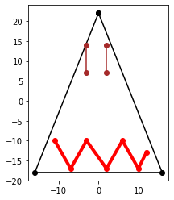

```python
crazy_hat_plot()
```

```python
colors = {1:'black', 2: 'brown', 3: 'brown', 4: 'red'}
width = {1: 2, 2: 2, 3: 2, 4: 4}
def crazy_hat_transformation(function, function_parameter = None):
    transformation = []
    iterator = 1
    for i in range(0,4):
        transformation.append(crazy_hat[i]@function(function_parameter))
        crazy_hat[i] = transformation[i]
    for item in transformation:
        plt.plot( item[:,0] , item[:,1] , c= colors[iterator] , marker = 'o', linewidth = width[iterator])
        plt.axes().set_aspect('equal')
        iterator += 1
    plt.show()
```

1. (10pt) Now rotate Crazy hat 66 degree counterclockwise (and plot it).

```python
# Define a rotation function which returns the rotation matrix

def rotation(angle):
    radians = np.radians(angle)
    c, s = np.cos(radians), np.sin(radians)
    R = np.array(((c,-s), (s, c)))
    return R
```

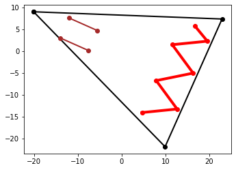

```python
#Call the crazy_hat transformation function to plot the rotated image
crazy_hat_transformation(rotation, -66)
```

# 2 Manipulate images: Flip and stretch (40pt)

In the previous section we rotated the Crazy Hat image. You next task is to flip it, stretch it, and finally combine all these transformations into a single transformation. If you are not a fan of Crazy Hat, you can also choose another image.

1. (15pt) Construct the flip-x that flips (mirrors) the image on y axis. It should mirror (flip) the x components but leave the y components untouched. Demonstrate this with Crazy Hat.

```python
# Define a reflection function that can be used to reflect the image over y-axis

def reflection(A):
    R = np.array([[-1,0], [0,1]])
    return R
```

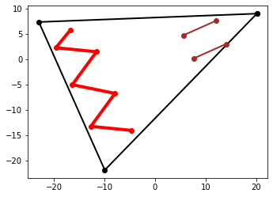

```python
# Call crazy_hat transformation function to flip the image
crazy_hat_transformation(reflection)
```

```python
# Define a stretch function that can be used to strect the image along y-axis

def stretch(stretch_factor):
    R = np.array([[1,0], [0,stretch_factor]])
    return R
```

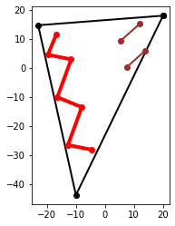

```python
# Call crazy_hat transformation function to stretch the image
crazy_hat_transformation(stretch, 2)
```

1. (5pt) Do the following operations after one another: rotate it by 45 degrees counterclockwise, flip it, stretch it 2×, and rotate it back.

```python
#Read the data again for various transformations
df = pd.read_csv('crazy-hat.tsv', sep = '\t')
crazy_hat = []
for i in groups:
    crazy_hat.append(df.where(df['group']==i).dropna()[["x", "y"]].values)

outline, left_eye, right_eye, mouth = crazy_hat
```

```
<module 'matplotlib.pyplot' from 'C:\\Users\\yashr\\Anaconda\\lib\\site-packages\\matplotlib\\pyplot.py'>
```

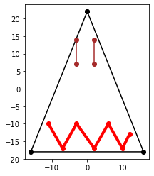

```python
# Plot original crazy_hat
crazy_hat_plot()
```

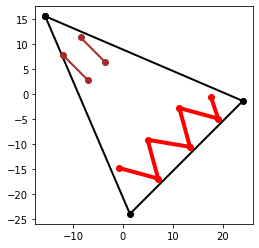

```python
# Call crazy_hat transformation function to rotate the image by 45 degrees counterclockwise
crazy_hat_transformation(rotation, -45)
```

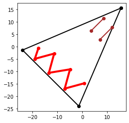

```python
# Call crazy_hat transformation function to flip the image
crazy_hat_transformation(reflection)
```

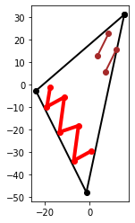

```python
# Call crazy_hat transformation function to stretch the image by 2 times
crazy_hat_transformation(stretch, 2)
```

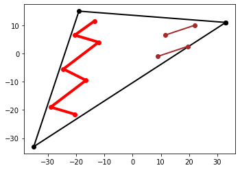

```python
# Call crazy_hat transformation function to rotate the image 45 degrees clockwise
crazy_hat_transformation(rotation, 45)
```

```python
#Matrix coordinates for outline, left eye, right eye and mouth features respectively
for i in crazy_hat:
    print(i)
    print('================')
```

```
[[ 33.  11.]
 [-19.  15.]
 [-35. -33.]
 [ 33.  11.]]
================
[[ 9.  -1. ]
 [19.5  2.5]]
================
[[11.5  6.5]
 [22.  10. ]]
================
[[-20.5 -21.5]
 [-29.  -19. ]
 [-16.5  -9.5]
 [-24.5  -5.5]
 [-12.    4. ]
 [-20.5   6.5]
 [-13.5  11.5]]
================
```

# 3. Manipulate bitmap images (30pt)

```python
from matplotlib.image import imread
```

[figure not shown]

```python
img = imread('dont-own-tv-small.png')
#select color channel
R = img[:,:,2]

#create coordinate matrix
xx,yy = np.meshgrid(np.arange(R.shape[1]),
                   np.arange(R.shape[0], 0, -1))

ImageMatrix = np.stack((xx.ravel(), yy.ravel()), axis=1)
fig = plt.figure(figsize=(5,5))
ax = fig.add_subplot(1,1,1)
ax.scatter(ImageMatrix[:,0], ImageMatrix[:,1], c=R.ravel(), marker='.', cmap="Greys_r")
ax.set_aspect('equal')
plt.show()
```

1. (15pt) Now stretch the image vertically (using the stretch-y matrix you did above) so that it will be square-shaped. Hint: you can compute the correct stretch factor using the original image shape your read with imread.

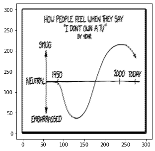

```python
img.shape

stretchS= 300/189

stretched_image= ImageMatrix @ stretch(stretchS)

fig = plt.figure(figsize=(5,5))
ax = fig.add_subplot(1,1,1)
ax.scatter(stretched_image[:,0], stretched_image[:,1], c=R.ravel(), marker='.', cmap="Greys_r")
ax.set_aspect('equal')
plt.show()
```

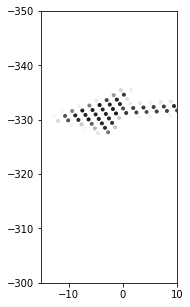

```python
Zoomed_in= stretched_image @ rotation(125)
fig = plt.figure(figsize=(5,5))
ax = fig.add_subplot(1,1,1)
ax.scatter(Zoomed_in[:,0], Zoomed_in[:,1], c=R.ravel(), marker='.', cmap="Greys_r")
ax.set_aspect('equal')
ax.set_xlim(-15,10)
ax.set_ylim(-300,-350)

plt.show()
```